# Risk Factor Analysis

## Outcome Variable

**Outcome Variable:** haz

## Predictor Variables

**Intervention Variable:** nhh

**Adjustment Set:**

- arm
- W_mage
- meducyrs
- feducyrs
- hhwealth_quart
- W_mhtcm
- W_mwtkg
- W_mbmi
- W_nrooms
- cleanck
- impfloor
- impsan
- safeh20
- delta_W_mage
- delta_meducyrs
- delta_feducyrs
- delta_hhwealth_quart
- delta_W_mhtcm
- delta_W_mwtkg
- delta_W_mbmi
- delta_W_nrooms
- delta_cleanck
- delta_impfloor
- delta_impsan
- delta_safeh20

## Stratifying Variables

The analysis was stratified on these variable(s):

- agecat
- studyid
- country

## Data Summary

| agecat | studyid | country | nhh | n_cell | n | outcome_variable |
| --- | --- | --- | --- | --- | --- | --- |
| Birth | ki1000108-IRC | INDIA | 3 or less | 54 | 388 | haz |
| Birth | ki1000108-IRC | INDIA | 4-5 | 150 | 388 | haz |
| Birth | ki1000108-IRC | INDIA | 6-7 | 103 | 388 | haz |
| Birth | ki1000108-IRC | INDIA | 8+ | 81 | 388 | haz |
| Birth | ki1017093-NIH-Birth | BANGLADESH | 3 or less | 112 | 608 | haz |
| Birth | ki1017093-NIH-Birth | BANGLADESH | 4-5 | 255 | 608 | haz |
| Birth | ki1017093-NIH-Birth | BANGLADESH | 6-7 | 138 | 608 | haz |
| Birth | ki1017093-NIH-Birth | BANGLADESH | 8+ | 103 | 608 | haz |
| Birth | ki1017093b-PROVIDE | BANGLADESH | 3 or less | 104 | 539 | haz |
| Birth | ki1017093b-PROVIDE | BANGLADESH | 4-5 | 251 | 539 | haz |
| Birth | ki1017093b-PROVIDE | BANGLADESH | 6-7 | 116 | 539 | haz |
| Birth | ki1017093b-PROVIDE | BANGLADESH | 8+ | 68 | 539 | haz |
| Birth | ki1017093c-NIH-Crypto | BANGLADESH | 3 or less | 108 | 732 | haz |
| Birth | ki1017093c-NIH-Crypto | BANGLADESH | 4-5 | 328 | 732 | haz |
| Birth | ki1017093c-NIH-Crypto | BANGLADESH | 6-7 | 176 | 732 | haz |
| Birth | ki1017093c-NIH-Crypto | BANGLADESH | 8+ | 120 | 732 | haz |
| 6 months | ki1000108-IRC | INDIA | 3 or less | 58 | 407 | haz |
| 6 months | ki1000108-IRC | INDIA | 4-5 | 158 | 407 | haz |
| 6 months | ki1000108-IRC | INDIA | 6-7 | 106 | 407 | haz |
| 6 months | ki1000108-IRC | INDIA | 8+ | 85 | 407 | haz |
| 6 months | ki1000304b-SAS-FoodSuppl | INDIA | 3 or less | 33 | 380 | haz |
| 6 months | ki1000304b-SAS-FoodSuppl | INDIA | 4-5 | 166 | 380 | haz |
| 6 months | ki1000304b-SAS-FoodSuppl | INDIA | 6-7 | 115 | 380 | haz |
| 6 months | ki1000304b-SAS-FoodSuppl | INDIA | 8+ | 66 | 380 | haz |
| 6 months | ki1017093-NIH-Birth | BANGLADESH | 3 or less | 95 | 537 | haz |
| 6 months | ki1017093-NIH-Birth | BANGLADESH | 4-5 | 227 | 537 | haz |
| 6 months | ki1017093-NIH-Birth | BANGLADESH | 6-7 | 128 | 537 | haz |
| 6 months | ki1017093-NIH-Birth | BANGLADESH | 8+ | 87 | 537 | haz |
| 6 months | ki1017093b-PROVIDE | BANGLADESH | 3 or less | 105 | 604 | haz |
| 6 months | ki1017093b-PROVIDE | BANGLADESH | 4-5 | 289 | 604 | haz |
| 6 months | ki1017093b-PROVIDE | BANGLADESH | 6-7 | 130 | 604 | haz |
| 6 months | ki1017093b-PROVIDE | BANGLADESH | 8+ | 80 | 604 | haz |
| 6 months | ki1017093c-NIH-Crypto | BANGLADESH | 3 or less | 104 | 715 | haz |
| 6 months | ki1017093c-NIH-Crypto | BANGLADESH | 4-5 | 326 | 715 | haz |
| 6 months | ki1017093c-NIH-Crypto | BANGLADESH | 6-7 | 170 | 715 | haz |
| 6 months | ki1017093c-NIH-Crypto | BANGLADESH | 8+ | 115 | 715 | haz |
| 6 months | ki1148112-LCNI-5 | MALAWI | 3 or less | 224 | 816 | haz |
| 6 months | ki1148112-LCNI-5 | MALAWI | 4-5 | 340 | 816 | haz |
| 6 months | ki1148112-LCNI-5 | MALAWI | 6-7 | 182 | 816 | haz |
| 6 months | ki1148112-LCNI-5 | MALAWI | 8+ | 70 | 816 | haz |
| 24 months | ki1000108-IRC | INDIA | 3 or less | 58 | 409 | haz |
| 24 months | ki1000108-IRC | INDIA | 4-5 | 158 | 409 | haz |
| 24 months | ki1000108-IRC | INDIA | 6-7 | 107 | 409 | haz |
| 24 months | ki1000108-IRC | INDIA | 8+ | 86 | 409 | haz |
| 24 months | ki1017093-NIH-Birth | BANGLADESH | 3 or less | 75 | 429 | haz |
| 24 months | ki1017093-NIH-Birth | BANGLADESH | 4-5 | 184 | 429 | haz |
| 24 months | ki1017093-NIH-Birth | BANGLADESH | 6-7 | 100 | 429 | haz |
| 24 months | ki1017093-NIH-Birth | BANGLADESH | 8+ | 70 | 429 | haz |
| 24 months | ki1017093b-PROVIDE | BANGLADESH | 3 or less | 106 | 578 | haz |
| 24 months | ki1017093b-PROVIDE | BANGLADESH | 4-5 | 273 | 578 | haz |
| 24 months | ki1017093b-PROVIDE | BANGLADESH | 6-7 | 117 | 578 | haz |
| 24 months | ki1017093b-PROVIDE | BANGLADESH | 8+ | 82 | 578 | haz |
| 24 months | ki1017093c-NIH-Crypto | BANGLADESH | 3 or less | 69 | 514 | haz |
| 24 months | ki1017093c-NIH-Crypto | BANGLADESH | 4-5 | 232 | 514 | haz |
| 24 months | ki1017093c-NIH-Crypto | BANGLADESH | 6-7 | 130 | 514 | haz |
| 24 months | ki1017093c-NIH-Crypto | BANGLADESH | 8+ | 83 | 514 | haz |
| 24 months | ki1148112-LCNI-5 | MALAWI | 3 or less | 159 | 574 | haz |
| 24 months | ki1148112-LCNI-5 | MALAWI | 4-5 | 237 | 574 | haz |
| 24 months | ki1148112-LCNI-5 | MALAWI | 6-7 | 129 | 574 | haz |
| 24 months | ki1148112-LCNI-5 | MALAWI | 8+ | 49 | 574 | haz |

The following strata were considered:

- agecat: 24 months, studyid: ki1000108-IRC, country: INDIA
- agecat: 24 months, studyid: ki1017093-NIH-Birth, country: BANGLADESH
- agecat: 24 months, studyid: ki1017093b-PROVIDE, country: BANGLADESH
- agecat: 24 months, studyid: ki1017093c-NIH-Crypto, country: BANGLADESH
- agecat: 24 months, studyid: ki1148112-LCNI-5, country: MALAWI
- agecat: 6 months, studyid: ki1000108-IRC, country: INDIA
- agecat: 6 months, studyid: ki1000304b-SAS-FoodSuppl, country: INDIA
- agecat: 6 months, studyid: ki1017093-NIH-Birth, country: BANGLADESH
- agecat: 6 months, studyid: ki1017093b-PROVIDE, country: BANGLADESH
- agecat: 6 months, studyid: ki1017093c-NIH-Crypto, country: BANGLADESH
- agecat: 6 months, studyid: ki1148112-LCNI-5, country: MALAWI
- agecat: Birth, studyid: ki1000108-IRC, country: INDIA
- agecat: Birth, studyid: ki1017093-NIH-Birth, country: BANGLADESH
- agecat: Birth, studyid: ki1017093b-PROVIDE, country: BANGLADESH
- agecat: Birth, studyid: ki1017093c-NIH-Crypto, country: BANGLADESH

## Methods Detail

We’re interested in the causal parameters $E[Y_a]$ for all values of $a \in \mathcal{A}$. These parameters represent the mean outcome if, possibly contrary to fact, we intervened to set all units to have $A=a$. Under the randomization and positivity assumptions, these are identified by the statistical parameters $\psi_a=E_W[E_{Y|A,W}(Y|A=a,W)]$. In addition, we’re interested in the mean of $Y$, $E[Y]$ under no intervention (the observed mean). We will estimate these parameters by using SuperLearner to fit the relevant likelihood factors – $E_{Y|A,W}(Y|A=a,W)$ and $p(A=a|W)$, and then updating our likelihood fit using a joint TMLE.

For unadjusted analyses ($W=\{\}$), initial likelihoods were estimated using Lrnr_glm to estimate the simple $E(Y|A)$ and Lrnr_mean to estimate $p(A)$. For adjusted analyses, a small library containing Lrnr_glmnet, Lrnr_xgboost, and Lrnr_mean was used.

Having estimated these parameters, we will then use the delta method to estimate relative risks and attributable risks relative to a prespecified baseline level of $A$.

# Results Detail

## Results Plots

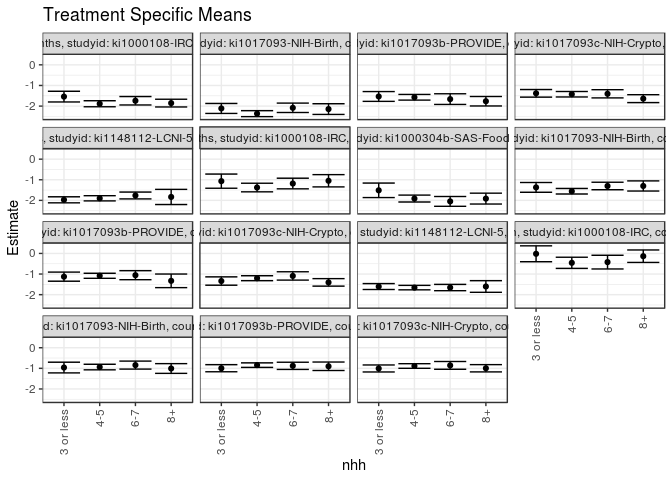

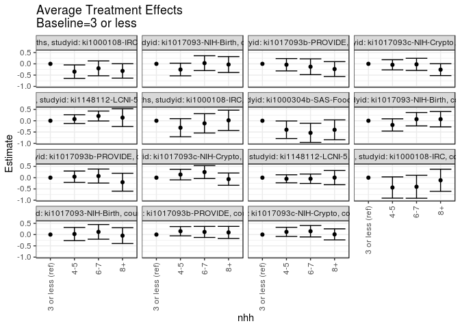

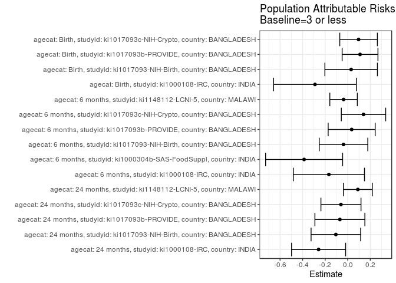

## Results Table

### Parameter: TSM

| agecat | studyid | country | intervention_level | baseline_level | estimate | ci_lower | ci_upper |
| --- | --- | --- | --- | --- | --- | --- | --- |
| Birth | ki1000108-IRC | INDIA | 3 or less | NA | -0.0175604 | -0.4029511 | 0.3678302 |
| Birth | ki1000108-IRC | INDIA | 4-5 | NA | -0.4545725 | -0.7255025 | -0.1836425 |
| Birth | ki1000108-IRC | INDIA | 6-7 | NA | -0.4208779 | -0.7530049 | -0.0887509 |
| Birth | ki1000108-IRC | INDIA | 8+ | NA | -0.1335928 | -0.4361951 | 0.1690096 |
| Birth | ki1017093-NIH-Birth | BANGLADESH | 3 or less | NA | -0.9613369 | -1.2203281 | -0.7023457 |
| Birth | ki1017093-NIH-Birth | BANGLADESH | 4-5 | NA | -0.9367672 | -1.0715159 | -0.8020185 |
| Birth | ki1017093-NIH-Birth | BANGLADESH | 6-7 | NA | -0.8421080 | -1.0364418 | -0.6477743 |
| Birth | ki1017093-NIH-Birth | BANGLADESH | 8+ | NA | -1.0077313 | -1.2434010 | -0.7720616 |
| Birth | ki1017093b-PROVIDE | BANGLADESH | 3 or less | NA | -0.9942946 | -1.1668465 | -0.8217427 |
| Birth | ki1017093b-PROVIDE | BANGLADESH | 4-5 | NA | -0.8443250 | -0.9545966 | -0.7340534 |
| Birth | ki1017093b-PROVIDE | BANGLADESH | 6-7 | NA | -0.8774567 | -1.0519684 | -0.7029450 |
| Birth | ki1017093b-PROVIDE | BANGLADESH | 8+ | NA | -0.8991974 | -1.1042086 | -0.6941862 |
| Birth | ki1017093c-NIH-Crypto | BANGLADESH | 3 or less | NA | -1.0056515 | -1.1759864 | -0.8353166 |
| Birth | ki1017093c-NIH-Crypto | BANGLADESH | 4-5 | NA | -0.8861946 | -0.9971433 | -0.7752458 |
| Birth | ki1017093c-NIH-Crypto | BANGLADESH | 6-7 | NA | -0.8565459 | -1.0451352 | -0.6679566 |
| Birth | ki1017093c-NIH-Crypto | BANGLADESH | 8+ | NA | -0.9956890 | -1.1719595 | -0.8194185 |
| 6 months | ki1000108-IRC | INDIA | 3 or less | NA | -1.0672708 | -1.4105332 | -0.7240083 |
| 6 months | ki1000108-IRC | INDIA | 4-5 | NA | -1.3758621 | -1.5845522 | -1.1671720 |
| 6 months | ki1000108-IRC | INDIA | 6-7 | NA | -1.1824156 | -1.4408029 | -0.9240283 |
| 6 months | ki1000108-IRC | INDIA | 8+ | NA | -1.0490151 | -1.3462357 | -0.7517944 |
| 6 months | ki1000304b-SAS-FoodSuppl | INDIA | 3 or less | NA | -1.5119499 | -1.8633807 | -1.1605192 |
| 6 months | ki1000304b-SAS-FoodSuppl | INDIA | 4-5 | NA | -1.9105913 | -2.0781775 | -1.7430051 |
| 6 months | ki1000304b-SAS-FoodSuppl | INDIA | 6-7 | NA | -2.0486465 | -2.2865147 | -1.8107783 |
| 6 months | ki1000304b-SAS-FoodSuppl | INDIA | 8+ | NA | -1.9136801 | -2.1767509 | -1.6506094 |
| 6 months | ki1017093-NIH-Birth | BANGLADESH | 3 or less | NA | -1.3698829 | -1.6067663 | -1.1329996 |
| 6 months | ki1017093-NIH-Birth | BANGLADESH | 4-5 | NA | -1.5563426 | -1.6903865 | -1.4222987 |
| 6 months | ki1017093-NIH-Birth | BANGLADESH | 6-7 | NA | -1.3016089 | -1.4832294 | -1.1199884 |
| 6 months | ki1017093-NIH-Birth | BANGLADESH | 8+ | NA | -1.3011517 | -1.5462366 | -1.0560669 |
| 6 months | ki1017093b-PROVIDE | BANGLADESH | 3 or less | NA | -1.1266323 | -1.3469211 | -0.9063436 |
| 6 months | ki1017093b-PROVIDE | BANGLADESH | 4-5 | NA | -1.0842108 | -1.2068170 | -0.9616046 |
| 6 months | ki1017093b-PROVIDE | BANGLADESH | 6-7 | NA | -1.0550923 | -1.2745457 | -0.8356388 |
| 6 months | ki1017093b-PROVIDE | BANGLADESH | 8+ | NA | -1.3287011 | -1.6576596 | -0.9997427 |
| 6 months | ki1017093c-NIH-Crypto | BANGLADESH | 3 or less | NA | -1.3385302 | -1.5406246 | -1.1364359 |
| 6 months | ki1017093c-NIH-Crypto | BANGLADESH | 4-5 | NA | -1.2008666 | -1.3207866 | -1.0809467 |
| 6 months | ki1017093c-NIH-Crypto | BANGLADESH | 6-7 | NA | -1.0910571 | -1.2937496 | -0.8883646 |
| 6 months | ki1017093c-NIH-Crypto | BANGLADESH | 8+ | NA | -1.4043369 | -1.5861954 | -1.2224784 |
| 6 months | ki1148112-LCNI-5 | MALAWI | 3 or less | NA | -1.6058074 | -1.7483875 | -1.4632274 |
| 6 months | ki1148112-LCNI-5 | MALAWI | 4-5 | NA | -1.6570833 | -1.7646339 | -1.5495326 |
| 6 months | ki1148112-LCNI-5 | MALAWI | 6-7 | NA | -1.6541707 | -1.8069626 | -1.5013787 |
| 6 months | ki1148112-LCNI-5 | MALAWI | 8+ | NA | -1.6028957 | -1.8849042 | -1.3208871 |
| 24 months | ki1000108-IRC | INDIA | 3 or less | NA | -1.5404297 | -1.8001358 | -1.2807236 |
| 24 months | ki1000108-IRC | INDIA | 4-5 | NA | -1.8862863 | -2.0325112 | -1.7400615 |
| 24 months | ki1000108-IRC | INDIA | 6-7 | NA | -1.7401106 | -1.9443242 | -1.5358970 |
| 24 months | ki1000108-IRC | INDIA | 8+ | NA | -1.8550904 | -2.0428606 | -1.6673201 |
| 24 months | ki1017093-NIH-Birth | BANGLADESH | 3 or less | NA | -2.1139068 | -2.3553120 | -1.8725015 |
| 24 months | ki1017093-NIH-Birth | BANGLADESH | 4-5 | NA | -2.3662851 | -2.5108633 | -2.2217069 |
| 24 months | ki1017093-NIH-Birth | BANGLADESH | 6-7 | NA | -2.0833300 | -2.3109534 | -1.8557066 |
| 24 months | ki1017093-NIH-Birth | BANGLADESH | 8+ | NA | -2.1447225 | -2.4035827 | -1.8858624 |
| 24 months | ki1017093b-PROVIDE | BANGLADESH | 3 or less | NA | -1.5328834 | -1.7706601 | -1.2951068 |
| 24 months | ki1017093b-PROVIDE | BANGLADESH | 4-5 | NA | -1.5722790 | -1.7091781 | -1.4353799 |
| 24 months | ki1017093b-PROVIDE | BANGLADESH | 6-7 | NA | -1.6617189 | -1.9203363 | -1.4031015 |
| 24 months | ki1017093b-PROVIDE | BANGLADESH | 8+ | NA | -1.7647611 | -1.9948312 | -1.5346909 |
| 24 months | ki1017093c-NIH-Crypto | BANGLADESH | 3 or less | NA | -1.3812551 | -1.5651546 | -1.1973556 |
| 24 months | ki1017093c-NIH-Crypto | BANGLADESH | 4-5 | NA | -1.4243402 | -1.5574275 | -1.2912529 |
| 24 months | ki1017093c-NIH-Crypto | BANGLADESH | 6-7 | NA | -1.4043862 | -1.6028494 | -1.2059230 |
| 24 months | ki1017093c-NIH-Crypto | BANGLADESH | 8+ | NA | -1.6390259 | -1.8303869 | -1.4476649 |
| 24 months | ki1148112-LCNI-5 | MALAWI | 3 or less | NA | -1.9720902 | -2.1184747 | -1.8257058 |
| 24 months | ki1148112-LCNI-5 | MALAWI | 4-5 | NA | -1.8988542 | -2.0256470 | -1.7720613 |
| 24 months | ki1148112-LCNI-5 | MALAWI | 6-7 | NA | -1.7618999 | -1.9274947 | -1.5963050 |
| 24 months | ki1148112-LCNI-5 | MALAWI | 8+ | NA | -1.8332804 | -2.2011700 | -1.4653908 |

### Parameter: E(Y)

| agecat | studyid | country | intervention_level | baseline_level | estimate | ci_lower | ci_upper |
| --- | --- | --- | --- | --- | --- | --- | --- |
| Birth | ki1000108-IRC | INDIA | NA | NA | -0.3080412 | -0.4687931 | -0.1472894 |
| Birth | ki1017093-NIH-Birth | BANGLADESH | NA | NA | -0.9310197 | -1.0197391 | -0.8423003 |
| Birth | ki1017093b-PROVIDE | BANGLADESH | NA | NA | -0.8851020 | -0.9601332 | -0.8100709 |
| Birth | ki1017093c-NIH-Crypto | BANGLADESH | NA | NA | -0.9094945 | -0.9809370 | -0.8380521 |
| 6 months | ki1000108-IRC | INDIA | NA | NA | -1.2344062 | -1.3658524 | -1.1029600 |
| 6 months | ki1000304b-SAS-FoodSuppl | INDIA | NA | NA | -1.8986842 | -2.0118892 | -1.7854792 |
| 6 months | ki1017093-NIH-Birth | BANGLADESH | NA | NA | -1.4073821 | -1.4960598 | -1.3187043 |
| 6 months | ki1017093b-PROVIDE | BANGLADESH | NA | NA | -1.0916915 | -1.1661176 | -1.0172654 |
| 6 months | ki1017093c-NIH-Crypto | BANGLADESH | NA | NA | -1.1986783 | -1.2700937 | -1.1272630 |
| 6 months | ki1148112-LCNI-5 | MALAWI | NA | NA | -1.6426961 | -1.7120603 | -1.5733318 |
| 24 months | ki1000108-IRC | INDIA | NA | NA | -1.7987775 | -1.8923914 | -1.7051636 |
| 24 months | ki1017093-NIH-Birth | BANGLADESH | NA | NA | -2.2190579 | -2.3217459 | -2.1163699 |
| 24 months | ki1017093b-PROVIDE | BANGLADESH | NA | NA | -1.6024221 | -1.6857420 | -1.5191023 |
| 24 months | ki1017093c-NIH-Crypto | BANGLADESH | NA | NA | -1.4412646 | -1.5249156 | -1.3576135 |
| 24 months | ki1148112-LCNI-5 | MALAWI | NA | NA | -1.8822648 | -1.9637218 | -1.8008078 |

### Parameter: ATE

| agecat | studyid | country | intervention_level | baseline_level | estimate | ci_lower | ci_upper |
| --- | --- | --- | --- | --- | --- | --- | --- |
| Birth | ki1000108-IRC | INDIA | 3 or less | 3 or less | 0.0000000 | 0.0000000 | 0.0000000 |
| Birth | ki1000108-IRC | INDIA | 4-5 | 3 or less | -0.4370120 | -0.9079188 | 0.0338947 |
| Birth | ki1000108-IRC | INDIA | 6-7 | 3 or less | -0.4033175 | -0.9119849 | 0.1053500 |
| Birth | ki1000108-IRC | INDIA | 8+ | 3 or less | -0.1160323 | -0.6071561 | 0.3750914 |
| Birth | ki1017093-NIH-Birth | BANGLADESH | 3 or less | 3 or less | 0.0000000 | 0.0000000 | 0.0000000 |
| Birth | ki1017093-NIH-Birth | BANGLADESH | 4-5 | 3 or less | 0.0245697 | -0.2674559 | 0.3165953 |
| Birth | ki1017093-NIH-Birth | BANGLADESH | 6-7 | 3 or less | 0.1192289 | -0.2046575 | 0.4431152 |
| Birth | ki1017093-NIH-Birth | BANGLADESH | 8+ | 3 or less | -0.0463944 | -0.3965365 | 0.3037477 |
| Birth | ki1017093b-PROVIDE | BANGLADESH | 3 or less | 3 or less | 0.0000000 | 0.0000000 | 0.0000000 |
| Birth | ki1017093b-PROVIDE | BANGLADESH | 4-5 | 3 or less | 0.1499696 | -0.0545089 | 0.3544481 |
| Birth | ki1017093b-PROVIDE | BANGLADESH | 6-7 | 3 or less | 0.1168379 | -0.1284180 | 0.3620938 |
| Birth | ki1017093b-PROVIDE | BANGLADESH | 8+ | 3 or less | 0.0950972 | -0.1726567 | 0.3628510 |
| Birth | ki1017093c-NIH-Crypto | BANGLADESH | 3 or less | 3 or less | 0.0000000 | 0.0000000 | 0.0000000 |
| Birth | ki1017093c-NIH-Crypto | BANGLADESH | 4-5 | 3 or less | 0.1194569 | -0.0833685 | 0.3222823 |
| Birth | ki1017093c-NIH-Crypto | BANGLADESH | 6-7 | 3 or less | 0.1491056 | -0.1046673 | 0.4028785 |
| Birth | ki1017093c-NIH-Crypto | BANGLADESH | 8+ | 3 or less | 0.0099625 | -0.2345990 | 0.2545239 |
| 6 months | ki1000108-IRC | INDIA | 3 or less | 3 or less | 0.0000000 | 0.0000000 | 0.0000000 |
| 6 months | ki1000108-IRC | INDIA | 4-5 | 3 or less | -0.3085913 | -0.7091947 | 0.0920121 |
| 6 months | ki1000108-IRC | INDIA | 6-7 | 3 or less | -0.1151448 | -0.5433319 | 0.3130422 |
| 6 months | ki1000108-IRC | INDIA | 8+ | 3 or less | 0.0182557 | -0.4324546 | 0.4689660 |
| 6 months | ki1000304b-SAS-FoodSuppl | INDIA | 3 or less | 3 or less | 0.0000000 | 0.0000000 | 0.0000000 |
| 6 months | ki1000304b-SAS-FoodSuppl | INDIA | 4-5 | 3 or less | -0.3986414 | -0.7879690 | -0.0093138 |
| 6 months | ki1000304b-SAS-FoodSuppl | INDIA | 6-7 | 3 or less | -0.5366965 | -0.9608599 | -0.1125332 |
| 6 months | ki1000304b-SAS-FoodSuppl | INDIA | 8+ | 3 or less | -0.4017302 | -0.8414393 | 0.0379789 |
| 6 months | ki1017093-NIH-Birth | BANGLADESH | 3 or less | 3 or less | 0.0000000 | 0.0000000 | 0.0000000 |
| 6 months | ki1017093-NIH-Birth | BANGLADESH | 4-5 | 3 or less | -0.1864597 | -0.4586497 | 0.0857304 |
| 6 months | ki1017093-NIH-Birth | BANGLADESH | 6-7 | 3 or less | 0.0682741 | -0.2294849 | 0.3660331 |
| 6 months | ki1017093-NIH-Birth | BANGLADESH | 8+ | 3 or less | 0.0687312 | -0.2716847 | 0.4091471 |
| 6 months | ki1017093b-PROVIDE | BANGLADESH | 3 or less | 3 or less | 0.0000000 | 0.0000000 | 0.0000000 |
| 6 months | ki1017093b-PROVIDE | BANGLADESH | 4-5 | 3 or less | 0.0424216 | -0.2099260 | 0.2947692 |
| 6 months | ki1017093b-PROVIDE | BANGLADESH | 6-7 | 3 or less | 0.0715401 | -0.2391095 | 0.3821896 |
| 6 months | ki1017093b-PROVIDE | BANGLADESH | 8+ | 3 or less | -0.2020688 | -0.5982119 | 0.1940742 |
| 6 months | ki1017093c-NIH-Crypto | BANGLADESH | 3 or less | 3 or less | 0.0000000 | 0.0000000 | 0.0000000 |
| 6 months | ki1017093c-NIH-Crypto | BANGLADESH | 4-5 | 3 or less | 0.1376636 | -0.0974934 | 0.3728205 |
| 6 months | ki1017093c-NIH-Crypto | BANGLADESH | 6-7 | 3 or less | 0.2474731 | -0.0390152 | 0.5339614 |
| 6 months | ki1017093c-NIH-Crypto | BANGLADESH | 8+ | 3 or less | -0.0658067 | -0.3378744 | 0.2062610 |
| 6 months | ki1148112-LCNI-5 | MALAWI | 3 or less | 3 or less | 0.0000000 | 0.0000000 | 0.0000000 |
| 6 months | ki1148112-LCNI-5 | MALAWI | 4-5 | 3 or less | -0.0512758 | -0.2299861 | 0.1274344 |
| 6 months | ki1148112-LCNI-5 | MALAWI | 6-7 | 3 or less | -0.0483632 | -0.2573687 | 0.1606422 |
| 6 months | ki1148112-LCNI-5 | MALAWI | 8+ | 3 or less | 0.0029118 | -0.3132499 | 0.3190734 |
| 24 months | ki1000108-IRC | INDIA | 3 or less | 3 or less | 0.0000000 | 0.0000000 | 0.0000000 |
| 24 months | ki1000108-IRC | INDIA | 4-5 | 3 or less | -0.3458566 | -0.6435293 | -0.0481839 |
| 24 months | ki1000108-IRC | INDIA | 6-7 | 3 or less | -0.1996809 | -0.5292169 | 0.1298551 |
| 24 months | ki1000108-IRC | INDIA | 8+ | 3 or less | -0.3146607 | -0.6347694 | 0.0054481 |
| 24 months | ki1017093-NIH-Birth | BANGLADESH | 3 or less | 3 or less | 0.0000000 | 0.0000000 | 0.0000000 |
| 24 months | ki1017093-NIH-Birth | BANGLADESH | 4-5 | 3 or less | -0.2523783 | -0.5319236 | 0.0271669 |
| 24 months | ki1017093-NIH-Birth | BANGLADESH | 6-7 | 3 or less | 0.0305768 | -0.2989373 | 0.3600908 |
| 24 months | ki1017093-NIH-Birth | BANGLADESH | 8+ | 3 or less | -0.0308157 | -0.3831381 | 0.3215066 |
| 24 months | ki1017093b-PROVIDE | BANGLADESH | 3 or less | 3 or less | 0.0000000 | 0.0000000 | 0.0000000 |
| 24 months | ki1017093b-PROVIDE | BANGLADESH | 4-5 | 3 or less | -0.0393956 | -0.3129251 | 0.2341339 |
| 24 months | ki1017093b-PROVIDE | BANGLADESH | 6-7 | 3 or less | -0.1288354 | -0.4795426 | 0.2218718 |
| 24 months | ki1017093b-PROVIDE | BANGLADESH | 8+ | 3 or less | -0.2318776 | -0.5617108 | 0.0979556 |
| 24 months | ki1017093c-NIH-Crypto | BANGLADESH | 3 or less | 3 or less | 0.0000000 | 0.0000000 | 0.0000000 |
| 24 months | ki1017093c-NIH-Crypto | BANGLADESH | 4-5 | 3 or less | -0.0430851 | -0.2685659 | 0.1823957 |
| 24 months | ki1017093c-NIH-Crypto | BANGLADESH | 6-7 | 3 or less | -0.0231311 | -0.2922656 | 0.2460034 |
| 24 months | ki1017093c-NIH-Crypto | BANGLADESH | 8+ | 3 or less | -0.2577708 | -0.5215084 | 0.0059668 |
| 24 months | ki1148112-LCNI-5 | MALAWI | 3 or less | 3 or less | 0.0000000 | 0.0000000 | 0.0000000 |
| 24 months | ki1148112-LCNI-5 | MALAWI | 4-5 | 3 or less | 0.0732361 | -0.1199334 | 0.2664055 |
| 24 months | ki1148112-LCNI-5 | MALAWI | 6-7 | 3 or less | 0.2101904 | -0.0104311 | 0.4308119 |
| 24 months | ki1148112-LCNI-5 | MALAWI | 8+ | 3 or less | 0.1388098 | -0.2566840 | 0.5343037 |

### Parameter: PAR

| agecat | studyid | country | intervention_level | baseline_level | estimate | ci_lower | ci_upper |
| --- | --- | --- | --- | --- | --- | --- | --- |
| Birth | ki1000108-IRC | INDIA | 3 or less | NA | -0.2904808 | -0.6573632 | 0.0764015 |
| Birth | ki1017093-NIH-Birth | BANGLADESH | 3 or less | NA | 0.0303172 | -0.2026213 | 0.2632556 |
| Birth | ki1017093b-PROVIDE | BANGLADESH | 3 or less | NA | 0.1091925 | -0.0496569 | 0.2680420 |
| Birth | ki1017093c-NIH-Crypto | BANGLADESH | 3 or less | NA | 0.0961570 | -0.0705629 | 0.2628768 |
| 6 months | ki1000108-IRC | INDIA | 3 or less | NA | -0.1671355 | -0.4828335 | 0.1485626 |
| 6 months | ki1000304b-SAS-FoodSuppl | INDIA | 3 or less | NA | -0.3867343 | -0.7282876 | -0.0451809 |
| 6 months | ki1017093-NIH-Birth | BANGLADESH | 3 or less | NA | -0.0374991 | -0.2528954 | 0.1778972 |
| 6 months | ki1017093b-PROVIDE | BANGLADESH | 3 or less | NA | 0.0349408 | -0.1734742 | 0.2433558 |
| 6 months | ki1017093c-NIH-Crypto | BANGLADESH | 3 or less | NA | 0.1398519 | -0.0569135 | 0.3366172 |
| 6 months | ki1148112-LCNI-5 | MALAWI | 3 or less | NA | -0.0368886 | -0.1588388 | 0.0850615 |
| 24 months | ki1000108-IRC | INDIA | 3 or less | NA | -0.2583478 | -0.4980695 | -0.0186261 |
| 24 months | ki1017093-NIH-Birth | BANGLADESH | 3 or less | NA | -0.1051511 | -0.3250336 | 0.1147314 |
| 24 months | ki1017093b-PROVIDE | BANGLADESH | 3 or less | NA | -0.0695387 | -0.2910586 | 0.1519813 |
| 24 months | ki1017093c-NIH-Crypto | BANGLADESH | 3 or less | NA | -0.0600095 | -0.2377075 | 0.1176885 |
| 24 months | ki1148112-LCNI-5 | MALAWI | 3 or less | NA | 0.0898254 | -0.0379943 | 0.2176451 |